# Modern Data Mining - HW 2

Saurav Bose

Jason Liebmann

Nicole Berkman

## Problem 0

Review the code and concepts covered during lecture: model selection and penalized regression through elastic net.

## Problem 1: Model Selection

Do ISLR, page 262, problem 8, and write up the answer here. This question is designed to help understanding of model selection through simulations.

**(a)**

```r
#Set seed for our data
set.seed(40)
#Generate our predictor, X, of length n = 100
X <- rnorm(100)
#Generate error term, epsi, of the same length, n = 100
espi <- rnorm(100)
```

**(b)**

```r
#Choose Betas for our response vector Y
B0 <- 1
B1 <- 1
B2 <- 1
B3 <- 1
#Generate response vector Y of length n = 100
Y <- B0 + B1*X + B2*X^2 + B3*X^3 + espi
```

**(c)**

```r
#Create a data frame to hold to our dataset
data <- data.frame(y=Y, x1=X, x2=X^2, x3=X^3, x4=X^4, x5=X^5, x6=X^6, x7=X^7, x8=X^8, x9=X^9, x10=X^10)
#Run regsubsets to find the best model given our set of predictors
fit <- regsubsets(y ~ ., data = data, nvmax=25, method="exhaustive")
#show names of fit
names(fit)
```

```
##  [1] "np"        "nrbar"     "d"         "rbar"      "thetab"
##  [6] "first"     "last"      "vorder"    "tol"       "rss"
## [11] "bound"     "nvmax"     "ress"      "ir"        "nbest"
## [16] "lopt"      "il"        "ier"       "xnames"    "method"
## [21] "force.in"  "force.out" "sserr"     "intercept" "lindep"
## [26] "nullrss"   "nn"        "call"
```

```r
#assign summary of fit to variable f.e
f.e <- summary(fit)
```

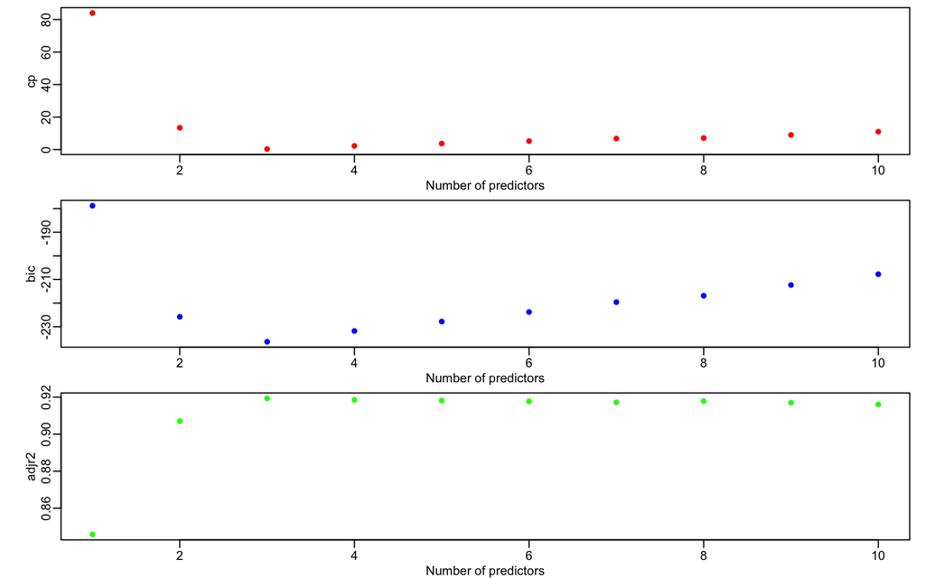

```r
#Graph Cp, bic and adj. R^2 graphs to see the minimum cp and bic to visually find the optimal number of predictors
par(mfrow=c(3,1), mar=c(2.5,4,0.5,1), mgp=c(1.5,0.5,0)) #makes sure all plots are graphed in one output
plot(f.e$cp, xlab="Number of predictors", ylab="cp", col="red", type="p", pch=16)
plot(f.e$bic, xlab="Number of predictors", ylab="bic", col="blue", type="p", pch=16)
plot(f.e$adjr2, xlab="Number of predictors", ylab="adjr2", col="green", type="p", pch=16)
```

Based on these plots, it appears that the best model is obtained with 3 predictors.

```r
#Get the optimal number of predictors
opt.size <- which.min(f.e$cp)
opt.size
```

```
## [1] 3
```

```r
#Now that we know the optimal number of predictors, find which 3 predictors we should use
fit.exh.var <- f.e$which
#tells you which variables to include in model
fit.exh.var[opt.size,]
```

```
## (Intercept)          x1          x2          x3          x4          x5
##        TRUE        TRUE        TRUE        TRUE       FALSE       FALSE
##          x6          x7          x8          x9         x10
##       FALSE       FALSE       FALSE       FALSE       FALSE
```

```r
#gives you column names of variables to include in the model
colnames(fit.exh.var)[fit.exh.var[opt.size,]]
```

```
## [1] "(Intercept)" "x1"          "x2"          "x3"
```

```r
#Run a regression on those predictors
fit.final <- lm(y ~ x1 + x2 + x3, data)
#summary of the lm model above (fit.final)
summary(fit.final)
```

```
##
## Call:
## lm(formula = y ~ x1 + x2 + x3, data = data)
##
## Residuals:
##     Min      1Q  Median      3Q     Max
## -2.6002 -0.6929 -0.1118  0.5855  3.3251
##
## Coefficients:
##             Estimate Std. Error t value Pr(>|t|)
## (Intercept)  1.00669    0.14991   6.715 1.32e-09 ***
## x1           0.85557    0.21582   3.964 0.000142 ***
## x2           0.95646    0.10334   9.256 5.91e-15 ***
## x3           1.01384    0.08761  11.573  < 2e-16 ***
## ---
## Signif. codes:  0 '***' 0.001 '**' 0.01 '*' 0.05 '.' 0.1 ' ' 1
##
## Residual standard error: 1.076 on 96 degrees of freedom
## Multiple R-squared:  0.9217, Adjusted R-squared:  0.9193
## F-statistic: 376.9 on 3 and 96 DF,  p-value: < 2.2e-16
```

**(d)** Forward Selection:

```r
#Run regsubsets using forward selection instead of exhaustive
fit.forward <- regsubsets(y ~., data = data, nvmax=25, method="forward")
#get summary of fit.forward
f.f <- summary(fit.forward)
f.f
```

```
## Subset selection object
## Call: regsubsets.formula(y ~ ., data = data, nvmax = 25, method = "forward")
## 10 Variables  (and intercept)
##     Forced in Forced out
## x1      FALSE      FALSE
## x2      FALSE      FALSE
## x3      FALSE      FALSE
## x4      FALSE      FALSE
## x5      FALSE      FALSE
## x6      FALSE      FALSE
## x7      FALSE      FALSE
## x8      FALSE      FALSE
## x9      FALSE      FALSE
## x10     FALSE      FALSE
## 1 subsets of each size up to 10
## Selection Algorithm: forward
##           x1  x2  x3  x4  x5  x6  x7  x8  x9  x10
## 1  ( 1 )  " " " " "*" " " " " " " " " " " " " " "
## 2  ( 1 )  " " "*" "*" " " " " " " " " " " " " " "
## 3  ( 1 )  "*" "*" "*" " " " " " " " " " " " " " "
## 4  ( 1 )  "*" "*" "*" " " " " " " " " " " " " "*"
## 5  ( 1 )  "*" "*" "*" " " " " " " " " "*" " " "*"
## 6  ( 1 )  "*" "*" "*" " " " " " " " " "*" "*" "*"
## 7  ( 1 )  "*" "*" "*" " " " " "*" " " "*" "*" "*"
## 8  ( 1 )  "*" "*" "*" " " " " "*" "*" "*" "*" "*"
## 9  ( 1 )  "*" "*" "*" " " "*" "*" "*" "*" "*" "*"
## 10  ( 1 ) "*" "*" "*" "*" "*" "*" "*" "*" "*" "*"
```

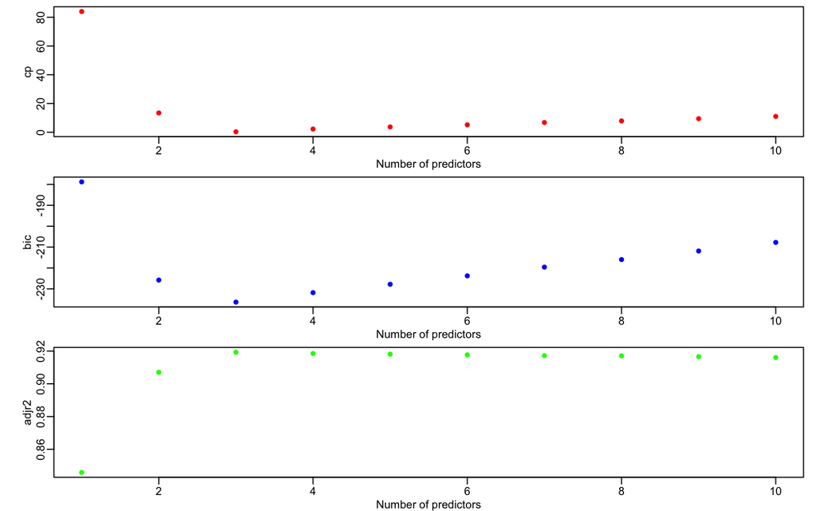

```r
#Graph Cp, bic and adj. R^2 graphs to see the minimum cp and bic to visually find the optimal number of predictors
par(mfrow=c(3,1), mar=c(2.5,4,0.5,1), mgp=c(1.5,0.5,0)) #makes sure all plots are graphed in one output
plot(f.f$cp, xlab="Number of predictors", ylab="cp", col="red", type="p", pch=16)
plot(f.f$bic, xlab="Number of predictors", ylab="bic", col="blue", type="p", pch=16)
plot(f.f$adjr2, xlab="Number of predictors", ylab="adjr2", col="green", type="p", pch=16)
```

```r
#Get the optimal number of predictors
opt.size.f <- which.min(f.f$cp)
opt.size.f
```

```
## [1] 3
```

```r
#get coefficients of those predicotrs
coef(fit.forward, 3)
```

```
## (Intercept)          x1          x2          x3
##   1.0066947   0.8555719   0.9564615   1.0138406
```

```r
#get summary of lm model for the three optimal predictors
summary(lm(y ~ x1 + x2 + x3, data))
```

```
##
## Call:
## lm(formula = y ~ x1 + x2 + x3, data = data)
##
## Residuals:
##     Min      1Q  Median      3Q     Max
## -2.6002 -0.6929 -0.1118  0.5855  3.3251
##
## Coefficients:
##             Estimate Std. Error t value Pr(>|t|)
## (Intercept)  1.00669    0.14991   6.715 1.32e-09 ***
## x1           0.85557    0.21582   3.964 0.000142 ***
## x2           0.95646    0.10334   9.256 5.91e-15 ***
## x3           1.01384    0.08761  11.573  < 2e-16 ***
## ---
## Signif. codes:  0 '***' 0.001 '**' 0.01 '*' 0.05 '.' 0.1 ' ' 1
##
## Residual standard error: 1.076 on 96 degrees of freedom
## Multiple R-squared:  0.9217, Adjusted R-squared:  0.9193
## F-statistic: 376.9 on 3 and 96 DF,  p-value: < 2.2e-16
```

Best model obtained with forward search: $Y = 1.00669 + 0.85557X + 0.95646X^2 + 1.01384X^3$

Backward Selection:

```r
#Run regsubsets using backward selection
fit.backward <- regsubsets(y ~., data = data, nvmax=25, method="backward")
#assign and get summary of backward selection
f.b <- summary(fit.backward)
f.b
```

```
## Subset selection object
## Call: regsubsets.formula(y ~ ., data = data, nvmax = 25, method = "backward")
## 10 Variables  (and intercept)
##     Forced in Forced out
## x1      FALSE      FALSE
## x2      FALSE      FALSE
## x3      FALSE      FALSE
## x4      FALSE      FALSE
## x5      FALSE      FALSE
## x6      FALSE      FALSE
## x7      FALSE      FALSE
## x8      FALSE      FALSE
## x9      FALSE      FALSE
## x10     FALSE      FALSE
## 1 subsets of each size up to 10
## Selection Algorithm: backward
##           x1  x2  x3  x4  x5  x6  x7  x8  x9  x10
## 1  ( 1 )  " " " " " " " " "*" " " " " " " " " " "
## 2  ( 1 )  "*" " " " " " " "*" " " " " " " " " " "
## 3  ( 1 )  "*" " " " " "*" "*" " " " " " " " " " "
## 4  ( 1 )  "*" " " " " "*" "*" "*" " " " " " " " "
## 5  ( 1 )  "*" " " " " "*" "*" "*" "*" " " " " " "
## 6  ( 1 )  "*" " " " " "*" "*" "*" "*" "*" " " " "
## 7  ( 1 )  "*" " " " " "*" "*" "*" "*" "*" " " "*"
## 8  ( 1 )  "*" " " " " "*" "*" "*" "*" "*" "*" "*"
## 9  ( 1 )  "*" " " "*" "*" "*" "*" "*" "*" "*" "*"
## 10  ( 1 ) "*" "*" "*" "*" "*" "*" "*" "*" "*" "*"
```

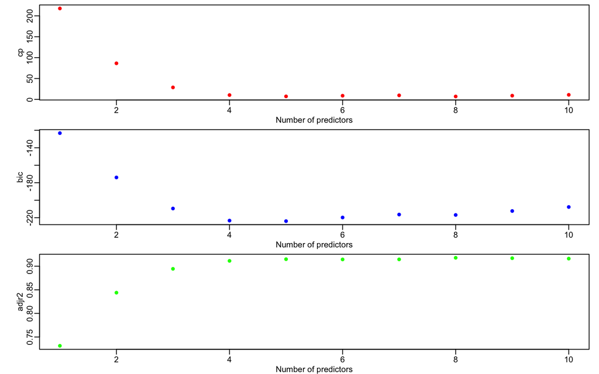

```r
#Graph Cp, bic and adj. R^2 graphs to see the minimum cp and bic to visually find the optimal number of predictors
par(mfrow=c(3,1), mar=c(2.5,4,0.5,1), mgp=c(1.5,0.5,0)) #makes sure all plots are graphed in one output
plot(f.b$cp, xlab="Number of predictors", ylab="cp", col="red", type="p", pch=16)
plot(f.b$bic, xlab="Number of predictors", ylab="bic", col="blue", type="p", pch=16)
plot(f.b$adjr2, xlab="Number of predictors", ylab="adjr2", col="green", type="p", pch=16)
```

```r
#Get the optimal number of predictors
opt.size.b <- which.min(f.b$cp)
opt.size.b
```

```
## [1] 8
```

```r
#Fit the model with the predictors and run a regression
#get coefficients for those predictors
coef(fit.backward, 3)
```

```
## (Intercept)          x1          x4          x5
##   1.4452414   1.9486548   0.2252403   0.1693986
```

```r
#get summary of lm model with the three optimal predictors
summary(lm(y ~ x1 + x4 + x5, data))
```

```
##
## Call:
## lm(formula = y ~ x1 + x4 + x5, data = data)
##
## Residuals:
##     Min      1Q  Median      3Q     Max
## -3.2622 -0.8559 -0.1714  0.8537  3.8324
##
## Coefficients:
##             Estimate Std. Error t value Pr(>|t|)
## (Intercept)  1.44524    0.14121  10.235  < 2e-16 ***
## x1           1.94865    0.17028  11.444  < 2e-16 ***
## x4           0.22524    0.03271   6.886 5.94e-10 ***
## x5           0.16940    0.01984   8.537 2.05e-13 ***
## ---
## Signif. codes:  0 '***' 0.001 '**' 0.01 '*' 0.05 '.' 0.1 ' ' 1
##
## Residual standard error: 1.231 on 96 degrees of freedom
## Multiple R-squared:  0.8976, Adjusted R-squared:  0.8944
## F-statistic: 280.6 on 3 and 96 DF,  p-value: < 2.2e-16
```

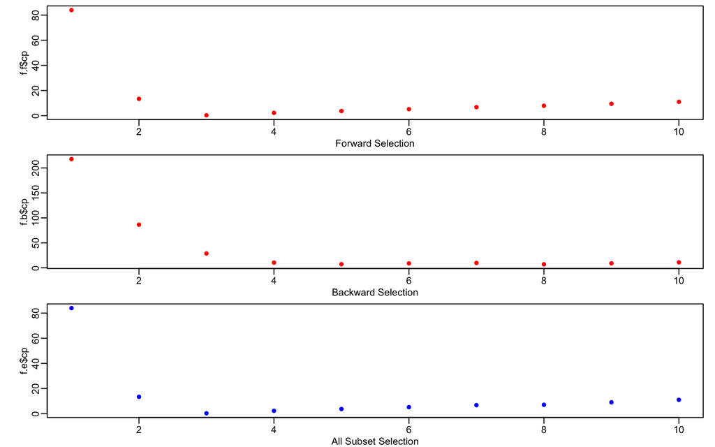

[output not shown]

```r
#Graphical comparison of all 3 methods using cp
par(mfrow=c(3,1), mar=c(2.5,4,0.5,1), mgp=c(1.5,0.5,0)) #makes sure all plots are graphed in one output
plot(f.f$cp,  col="red", type="p", pch=16, xlab="Forward Selection")
plot(f.b$cp,  col="red", type="p", pch=16, xlab="Backward Selection")
plot(f.e$cp,  col="blue", type="p", pch=16, xlab="All Subset Selection")
```

The models for exhaustive search and forward selection are pretty similar while the backward selection model gives us a model that uses different predictors.

**(e)**

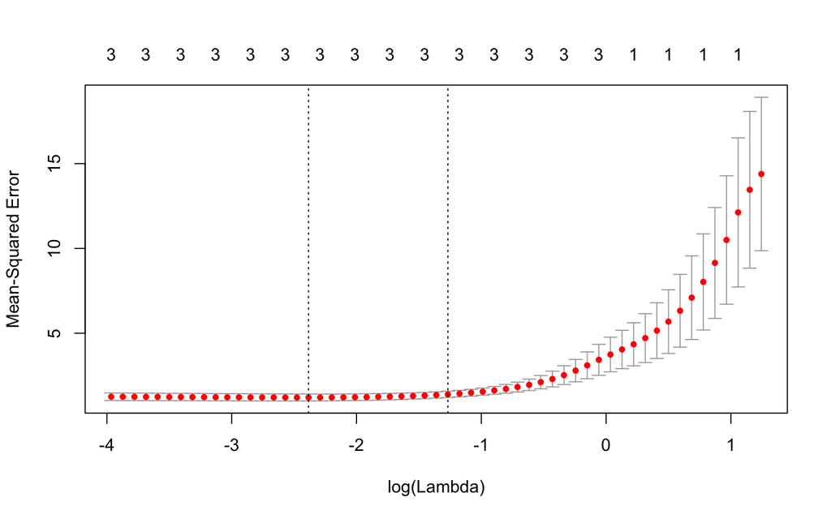

```r
#Get data into matrix form
X.lasso <- data.matrix(data[,-1])
#fit Lasso model
fit.cv <- cv.glmnet(X.lasso, Y, alpha=1, nfolds=10)
#Plot the lambdas
plot(fit.cv)
```

```r
coef.min <- coef(fit.cv, s="lambda.1se")
coef.min <- coef.min[which(coef.min !=0),]   # get the non=zero coefficients
coef.min  # the set of predictors chosen
```

```
## (Intercept)          x1          x2          x3
##   1.2694191   0.6119980   0.7139943   1.0045465
```

```r
rownames(as.matrix(coef.min)) # shows only names, not estimates
```

```
## [1] "(Intercept)" "x1"          "x2"          "x3"
```

**(f)** Data set up:

```r
#set up y response variable
Yf <- 1 + 7*X^7 + espi
#create dataframe for model
dataf <- data.frame(y=Yf, x1=X, x2=X^2, x3=X^3, x4=X^4, x5=X^5, x6=X^6, x7=X^7, x8=X^8, x9=X^9, x10=X^10)
```

Exhaustive Subset Selection

```r
#run exhaustive regsubset method on data
fit2 <- regsubsets(y ~ ., data = dataf, nvmax=25, method="exhaustive")
#get summary of exhasutive method
f.f2 <- summary(fit2)
```

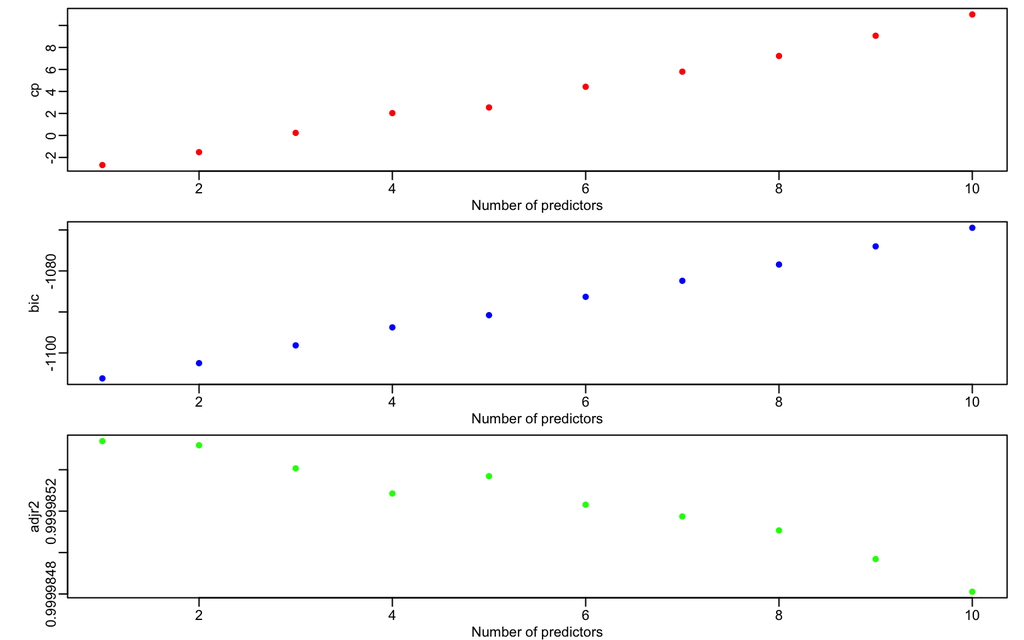

```r
#Graph Cp, bic and adj. R^2 graphs to see the minimum cp and bic to visually find the optimal number of predictors
par(mfrow=c(3,1), mar=c(2.5,4,0.5,1), mgp=c(1.5,0.5,0)) #makes sure all plots are graphed in one output
plot(f.f2$cp, xlab="Number of predictors", ylab="cp", col="red", type="p", pch=16)
plot(f.f2$bic, xlab="Number of predictors", ylab="bic", col="blue", type="p", pch=16)
plot(f.f2$adjr2, xlab="Number of predictors", ylab="adjr2", col="green", type="p", pch=16)
```

```r
#Get the optimal number of predictors
opt.size <- which.min(f.f2$cp)
opt.size
```

```
## [1] 1
```

```r
#Now that we know the optimal number of predictors, find which predictors we should use
fit.exh.var <- f.f2$which
fit.exh.var[opt.size,]
```

```
## (Intercept)          x1          x2          x3          x4          x5
##        TRUE       FALSE       FALSE       FALSE       FALSE       FALSE
##          x6          x7          x8          x9         x10
##       FALSE        TRUE       FALSE       FALSE       FALSE
```

```r
#gives you column names of variables to include in the model
colnames(fit.exh.var)[fit.exh.var[opt.size,]]
```

```
## [1] "(Intercept)" "x7"
```

```r
#Run a regression on those predictors
fit.f2.final <- lm(y ~ x7, dataf)
#summary of the model above
summary(fit.f2.final)
```

```
##
## Call:
## lm(formula = y ~ x7, data = dataf)
##
## Residuals:
##     Min      1Q  Median      3Q     Max
## -2.6053 -0.6557 -0.1201  0.5423  3.4534
##
## Coefficients:
##             Estimate Std. Error  t value Pr(>|t|)
## (Intercept) 0.959887   0.107410    8.937 2.45e-14 ***
## x7          6.998418   0.002675 2616.378  < 2e-16 ***
## ---
## Signif. codes:  0 '***' 0.001 '**' 0.01 '*' 0.05 '.' 0.1 ' ' 1
##
## Residual standard error: 1.071 on 98 degrees of freedom
## Multiple R-squared:      1,  Adjusted R-squared:      1
## F-statistic: 6.845e+06 on 1 and 98 DF,  p-value: < 2.2e-16
```

Lasso

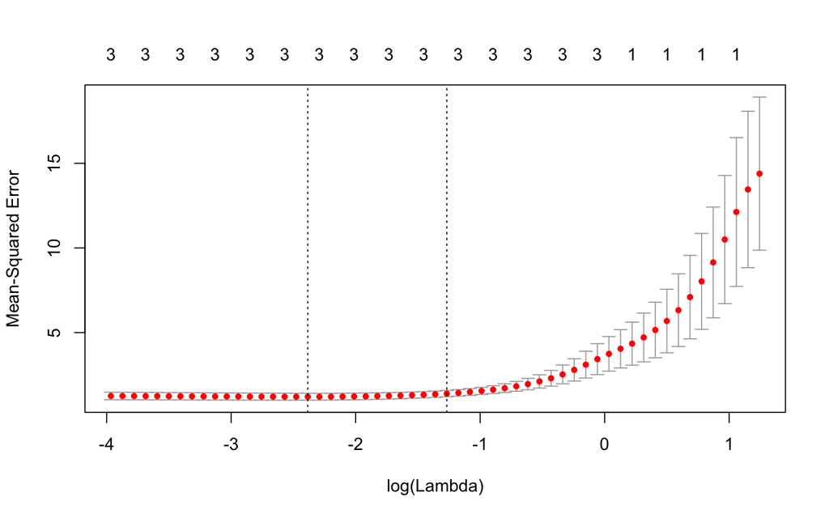

```r
fit.cv2 <- cv.glmnet(X.lasso, Yf, alpha=1, nfolds=10)
plot(fit.cv)   # plot the lambdas to have a visual representation of where lambda.min is
```

```r
coef.min <- coef(fit.cv2, s="lambda.min")
coef.min <- coef.min[which(coef.min !=0),]   # get the non=zero coefficients
coef.min  # the set of predictors chosen
```

```
## (Intercept)          x7
##    1.650863    6.774520
```

| Model Type | Best-fit Equation |
| --- | --- |
| Exhaustive Search | $Y = 0.959887 + 6.998418X^7$ |
| Lasso | $Y = 1.650863 + 6.774520X^7$ |

Both models are correct, but subset selection seems to be more accurate.

## Problem 2: Regularization

Crime data continuation: We use a subset of the crime data discussed in class, but only look at Florida and California. `crimedata` is available on Canvas; we show the code to clean here.

```r
crime.all <- read.csv("CrimeData.csv", stringsAsFactors = F, na.strings = c("?"))
crime <- dplyr::filter(crime.all, state %in% c("FL", "CA"))
```

Our goal is to find the factors which relate to violent crime. This variable is included in crime as `crime$violentcrimes.perpop`.

**A)** EDA

- Clean the data first

```r
#View column names for the data
names(crime)
```

```r
#View dimensions of the data
dim(crime)
```

```
## [1] 369 147
```

```r
#Find how many NA's are present in the data
sum(is.na(crime)) #We can't simply take out all of the na's because there is 7204 of them!
```

```
## [1] 7204
```

```r
#Find the dimensions of the data if we ommited all observations with an NA value
dim(na.omit(crime)) #This would omit all of our observations!
```

```
## [1]   0 147
```

```r
#take subset of data the excludes police data and various crimes
data1 <- crime[,c(2,6:103,121,122,123, 130:147)]
data1.all <- crime.all[,c(2,6:103,121,122,123, 130:147)]
names(data1)
```

- Prepare a set of sensible factors/variables that you may use to build a model

```r
names(data1[, 103:120]) #crime variables
```

```
##  [1] "num.murders"             "murder.perpop"
##  [3] "num.rapes"               "rapes.perpop"
##  [5] "num.robberies"           "robberies.perpop"
##  [7] "num.assaults"            "assaults.perpop"
##  [9] "num.burglaries"          "burglaries.perpop"
## [11] "num.larcenies"           "larcenies.perpop"
## [13] "num.autothefts"          "autothefts.perpop"
## [15] "num.arsons"              "arsons.perpop"
## [17] "violentcrimes.perpop"    "nonviolentcrimes.perpop"
```

```r
#continue to clean the data by taking these variables out
var_names_out <- c("num.urban","other.percap", "num.underpov",
                   "num.vacant.house","num.murders","num.rapes",
                   "num.robberies", "num.assaults", "num.burglaries",
                   "num.larcenies", "num.autothefts", "num.arsons")
data1 <- data1[!(names(data1) %in% var_names_out)]
data1.all <- data1.all[!(names(data1.all) %in% var_names_out)]

names_other_crimes <- c( "murder.perpop", "rapes.perpop",
                        "robberies.perpop",  "assaults.perpop",
                        "burglaries.perpop", "larcenies.perpop",
                        "autothefts.perpop", "arsons.perpop",
                         "nonviolentcrimes.perpop")
data2 <- data1[!(names(data1) %in% names_other_crimes)]
data2.all <- data1.all[!(names(data1.all) %in% names_other_crimes)]
```

```r
#further clean the data by ommiting rows with NA values
crime.neat <- na.omit(data2)
crime.neat.all <- na.omit(data2.all)
#get dimensions of cleaned data set
dim(crime.neat)
```

```
## [1] 368  99
```

- Show the heatmap with mean violent crime by state. You may also show a couple of your favorate summary statistics by state through the heatmaps.

```r
#Generating summary statistics like mean, median, standard deviation of violent crimes grouped by region.
sum.violent <- crime.neat.all %>% group_by(state) %>% summarise(mean.crime = mean(violentcrimes.perpop), med.crime = median(violentcrimes.perpop), sd.crime = sd(violentcrimes.perpop))
sum.violent
```

```
## # A tibble: 46 x 4
##    state mean.crime med.crime sd.crime
##    <chr>      <dbl>     <dbl>    <dbl>
##  1    AK   576.5767    742.54 405.6980
##  2    AL  1030.6991    759.91 954.0846
##  3    AR   718.5504    516.96 750.6835
##  4    AZ   551.0945    466.11 360.3172
##  5    CA   810.4694    641.84 580.2050
##  6    CO   526.8616    330.10 473.9789
##  7    CT   260.5996    108.52 430.4602
##  8    DC  3048.3800   3048.38       NA
##  9    DE   887.2900    887.29       NA
## 10    FL  1159.0469    965.52 826.8935
## # ... with 36 more rows
```

```r
#Matching state abbreviations to full forms
sum.violent$region <- tolower(state.name[match(sum.violent$state,state.abb)])
sum.violent$center.lat <- state.center$x[match(sum.violent$state,state.abb)]
sum.violent$center.long <- state.center$y[match(sum.violent$state, state.abb)]
#sum.violent
```

```r
#Creating a dataframe to plot the summary statistics on the map
states <- map_data("state")
map <- merge(states,sum.violent, sort = FALSE, by="region", all.x=TRUE)
#map
```

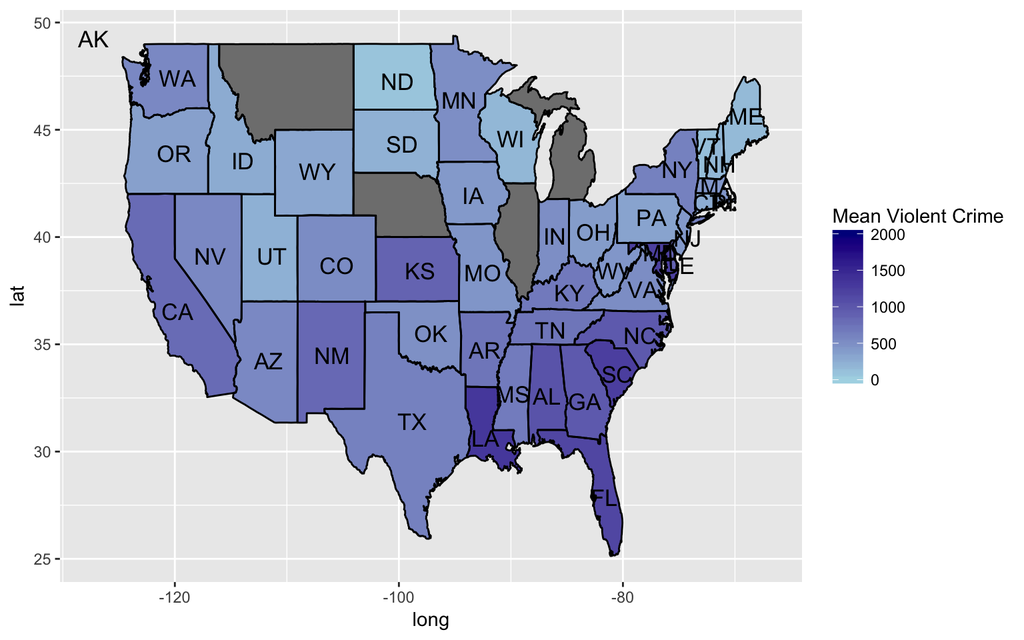

```r
#Plot of mean violent crimes by region
map <- map[order(map$order),]
ggplot(map, aes(x=long, y=lat, group=group))+
  geom_polygon(aes(fill=mean.crime))+
  geom_path()+
  geom_text(data=sum.violent, aes(x=center.lat, y=center.long, group=NA,
                             label=state, size=2), show.legend =FALSE)+
  scale_fill_continuous(limits=c(0, 2000),name="Mean Violent Crime",
                        low="light blue", high="dark blue")
```

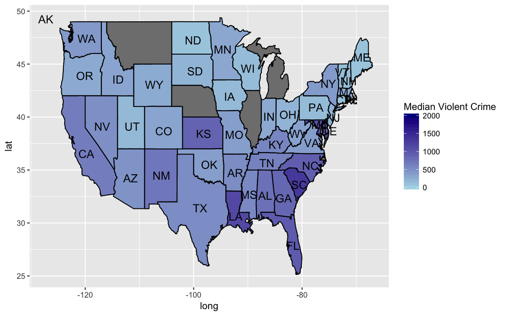

```r
#Plot of median viol;ent crimes by region
ggplot(map, aes(x=long, y=lat, group=group))+
  geom_polygon(aes(fill=med.crime))+
  geom_path()+
  geom_text(data=sum.violent, aes(x=center.lat, y=center.long, group=NA,
                             label=state, size=2), show.legend =FALSE)+
  scale_fill_continuous(limits=c(0, 2000),name="Median Violent Crime",
                        low="light blue", high="dark blue")
```

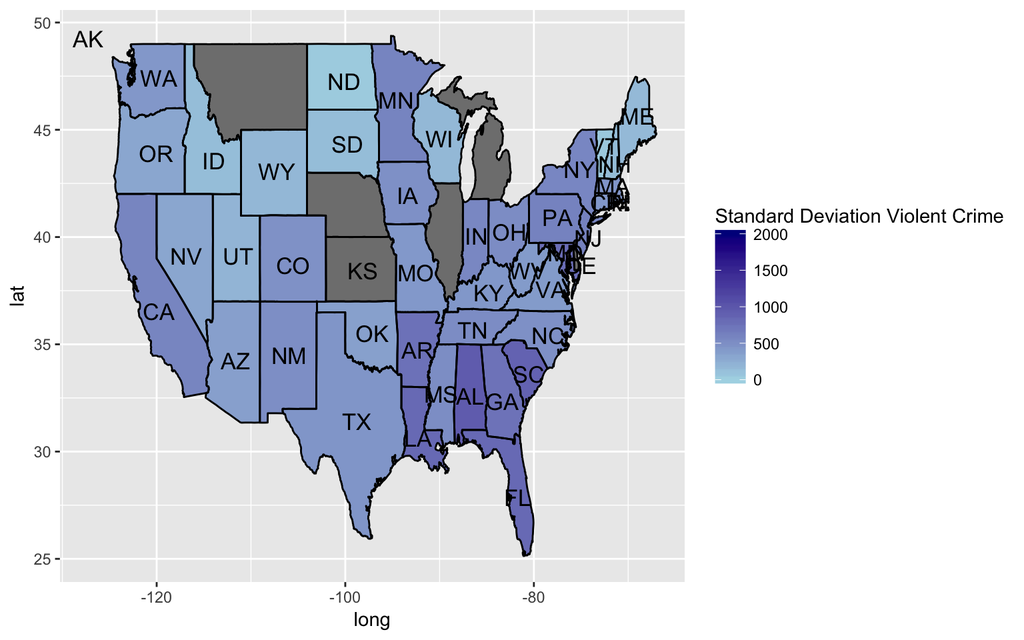

```r
#Plot of standard deviation of violent crimes by region
ggplot(map, aes(x=long, y=lat, group=group))+
  geom_polygon(aes(fill=sd.crime))+
  geom_path()+
  geom_text(data=sum.violent, aes(x=center.lat, y=center.long, group=NA,
                             label=state, size=2), show.legend =FALSE)+
  scale_fill_continuous(limits=c(0, 2000),name="Standard Deviation Violent Crime",
                        low="light blue", high="dark blue")
```

- Write a brief summary based on your EDA

We start with 147 columns and need to reduce this number in order to reduce the number of predictors we need to test and make our data easier to handle. However, upon inspecting the data, we see there are 7204 NA’s in the data, and we simply cannot omit them because then we wind up with zero observations. After further inspection of the dataframe, we see that most of the NAs come from the police data so we can remove those. Additionally, we decided not to use other crimes as predictors since we wanted to focus on predicting violent crimes with other predictors and not bias our predictions with the prevelance of other crimes; so we removed those as well. Finally, we removed any other rows with NA values, which only reduced our number of observations by 1 (from 369 to 368). All in all, we reduced the number of columsn from 147 to 99 and only lost one observation. From the heat maps, we observed that violent crimes were more prevelant in Florida as compared to California.

**B)** Use LASSO to choose a reasonable, small model. Fit an OLS model with the variables obtained. The final model should only include variables with p-values < 0.05. Note: you may choose to use lambda 1se or lambda min to answer the following questions where apply.

```r
#Extract Y
Crime.Y <- crime.neat[, 99]
#Get the X variables as a matrix. This will also code the categorical variables correctly.
Crime.X <- model.matrix(violentcrimes.perpop~., data=crime.neat)[, -1]
#get column names for the matrix
#colnames(Crime.X)
```

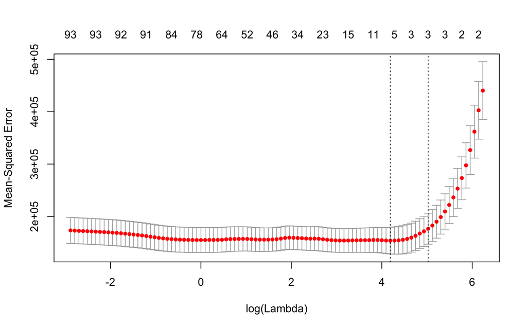

```r
set.seed(123)
crime.model <- cv.glmnet(Crime.X,Crime.Y, alpha=1, nfolds = 10)   #Run Lasso model and plot lamdbas
plot(crime.model)
```

```r
#assign data to new dataframe
crime.neat2 <- crime.neat
#assign data from first column of Crime.X to first column of crime.neat2
crime.neat2[,1] <- Crime.X[,1]
#get column names for crime.neat2 data set
names(crime.neat2)
```

```r
#rename column state to stateFL
crime.neat2 <- crime.neat2 %>% rename(stateFL = state)
#get column names for crime.neat2
names(crime.neat2)
```

```
##  [1] "stateFL"                         "population"
##  [3] "household.size"                  "race.pctblack"
##  [5] "race.pctwhite"                   "race.pctasian"
##  [7] "race.pcthisp"                    "age.pct12to21"
##  [9] "age.pct12to29"                   "age.pct16to24"
## [11] "age.pct65up"                     "pct.urban"
## [13] "med.income"                      "pct.wage.inc"
## [15] "pct.farmself.inc"                "pct.inv.inc"
## [17] "pct.socsec.inc"                  "pct.pubasst.inc"
## [19] "pct.retire"                      "med.family.inc"
## [21] "percap.inc"                      "white.percap"
## [23] "black.percap"                    "indian.percap"
## [25] "asian.percap"                    "hisp.percap"
## [27] "pct.pop.underpov"                "pct.less9thgrade"
## [29] "pct.not.hsgrad"                  "pct.bs.ormore"
```

[output cut: 35 more lines]

```r
crime.coef.min <- coef(crime.model, s="lambda.min")
crime.coef.min <- crime.coef.min[which(crime.coef.min !=0),]   # get the non=zero coefficients
var.min <- rownames(as.matrix(crime.coef.min)) # output the names
lm.input <- as.formula(paste("violentcrimes.perpop", "~", paste(var.min[-1], collapse = "+"))) # prepare for lm fomulae
lm.input
```

```
## violentcrimes.perpop ~ race.pctblack + pct.kids2parents + pct.kids.nvrmarried +
##     pct.house.vacant + num.in.shelters
```

We chose lambda min to fit the model because we wanted to choose the lambda that gave us the minimum prediction error. Moreover, lambda 1se shrunk the model to three freatures. This seemed like too simple a model and using it could underfit the data.

```r
fit.min.lm <- lm(lm.input, data=crime.neat2)
lm.output <- coef(fit.min.lm) # output lm estimates
summary(fit.min.lm)   #This is my OLS model
```

```
##
## Call:
## lm(formula = lm.input, data = crime.neat2)
##
## Residuals:
##      Min       1Q   Median       3Q      Max
## -1025.59  -214.47   -51.31   154.23  1900.04
##
## Coefficients:
##                       Estimate Std. Error t value Pr(>|t|)
## (Intercept)         1990.94020  261.64802   7.609 2.41e-13 ***
## race.pctblack         13.49803    2.71754   4.967 1.05e-06 ***
## pct.kids2parents     -22.51972    3.31167  -6.800 4.33e-11 ***
## pct.kids.nvrmarried   81.55397   12.68237   6.430 4.02e-10 ***
## pct.house.vacant      24.77046   10.96642   2.259   0.0245 *
## num.in.shelters        0.15868    0.05364   2.958   0.0033 **
## ---
## Signif. codes:  0 '***' 0.001 '**' 0.01 '*' 0.05 '.' 0.1 ' ' 1
##
## Residual standard error: 371.7 on 362 degrees of freedom
## Multiple R-squared:  0.692,  Adjusted R-squared:  0.6878
## F-statistic: 162.7 on 5 and 362 DF,  p-value: < 2.2e-16
```

```r
#Comparing the LASSO and OLS fit outputs
crime.comp <- data.frame(crime.coef.min, lm.output )
names(crime.comp) <- c("estimates from LASSO", "lm estimates")
crime.comp
```

```
##                     estimates from LASSO lm estimates
## (Intercept)                1889.76371524  1990.940195
## race.pctblack                10.30515531    13.498035
## pct.kids2parents            -20.08815960   -22.519720
## pct.kids.nvrmarried          82.06968615    81.553970
## pct.house.vacant              8.65658678    24.770465
## num.in.shelters               0.01740185     0.158676
```

Since all the variables are significant at the 0.05 level, the final model stays the same.

**C)** Now, instead of Lasso, we want to consider how changing the value of alpha (i.e. mixing between Lasso and Ridge) will affect the model. Cross-validate between alpha and lambda, instead of just lambda. Note that the final model may have variables with p-values higher than 0.05; this is because we are optimizing for accuracy rather than parsimoniousness.

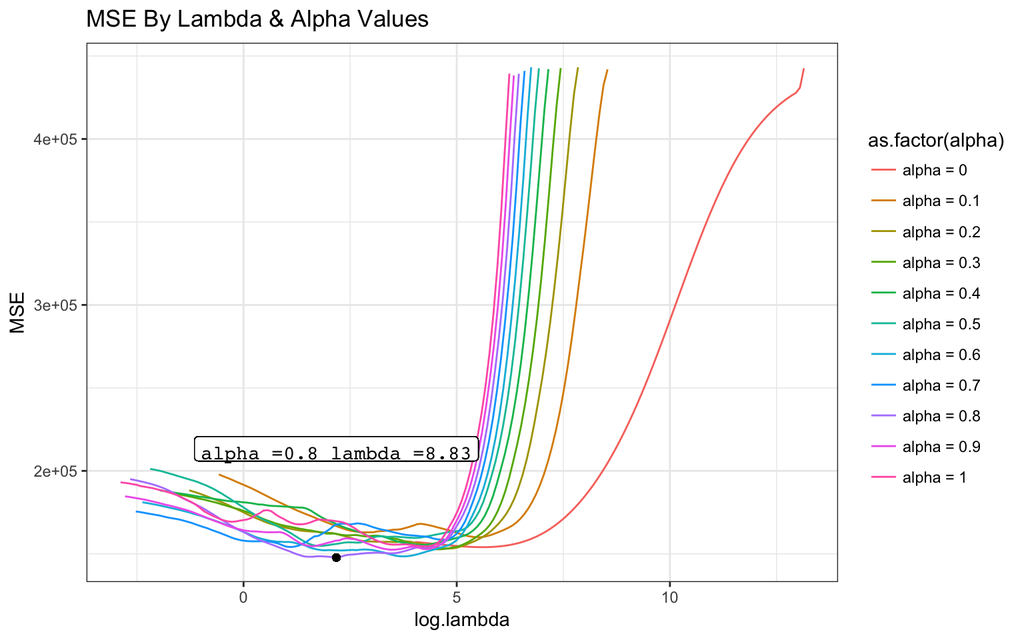

```r
set.seed(123)
#vector of alphas
a <- seq(0,1,.1)
#vector to hold the minimum cv errors for each alpha
min.cvm <- seq(0,1,.1)
#vector to hold the minimum lambda for each alpha
min.lambda <- seq(0,1,.1)
#lam.seq <- crime.model$lambda
MSE = NULL
Lambda = NULL

#Looping over alphas
for ( i in 1:length(a)){
  fit <- NULL
  #ensure fits are all of same length of lambdas
  while (length(fit$cvm) != 99) {
    fit <- cv.glmnet(Crime.X, Crime.Y, nfolds=10, alpha = a[i], nlambda = 100)
  }
  MSE <- cbind(MSE,fit$cvm)
  Lambda <- cbind(Lambda,fit$lambda)
  min.cvm[i] <- fit$cvm[match(fit$lambda.min,fit$lambda)]
  min.lambda[i] <-fit$lambda.min
}
#Dataframe of log lambdas for each alpha
df.l <- data.frame(log(Lambda))
#Dataframe of cv errors for each alpha
df.e <- data.frame(MSE)
colnames(df.l) <- paste0("alpha = ",seq(0,1,.1))
colnames(df.e) <- paste0("alpha = ",seq(0,1,.1))

df.l <- reshape2::melt(df.l)
df.e <- reshape2::melt(df.e)

df.tot <- cbind(df.l,df.e)
colnames(df.tot) <- c("alpha","log.lambda","alpha.y","MSE")

#Lambda corresponding to minimum cv error across alphas
l <- min.lambda[match(min(min.cvm),min.cvm)]
#Alpha for the lambda above
alp <- a[match(min(min.cvm),min.cvm)]
l.round <- round(l,2)

ggplot(df.tot, aes(x = log.lambda , y = MSE, color = as.factor(alpha))) + geom_line() + theme_bw()  + geom_point( aes(x = log(l) , y = min(df.tot$MSE)) , color = "black" ) + geom_label(aes(x= log(l), y = min(df.tot$MSE) , label = paste0("alpha =",alp," lambda =",l.round)),family = "Courier" , color = "black", vjust = -4) + labs(title = "MSE By Lambda & Alpha Values")
```

1. What is your final elastic net model? What were the alpha and lambda values? What is the prediction error?

```r
#For the lambda and alpha that gave minimum cv error, fit an elastic net
fit.lambda <- glmnet(Crime.X, Crime.Y, alpha = alp , lambda = l)

coef.min <- coef(fit.lambda)
coef.min <- coef.min[which(coef.min !=0),]# get the non=zero coefficients
coef.min
```

```
##                     (Intercept)                         stateFL
##                    9.644412e+03                    1.173242e+02
##                  household.size                   race.pctblack
##                   -1.491873e+02                    2.063564e+01
##                   age.pct12to21                       pct.urban
##                    1.245010e+01                    3.466924e-01
##                pct.farmself.inc                     pct.inv.inc
##                   -2.759989e+01                   -5.203067e+00
##                 pct.pubasst.inc                      pct.retire
##                    5.394201e+00                   -1.793237e+00
##                   indian.percap                    asian.percap
##                    4.408910e-04                    6.067804e-03
##                  pct.unemployed                    pct.employed
##                   -3.805953e+00                    1.694694e+00
##                male.pct.divorce             male.pct.nvrmarried
##                    3.715548e+01                    1.075772e+00
##                pct.kids2parents           pct.youngkids2parents
##                   -8.543467e+00                   -2.701470e+00
##                     pct.workmom             num.kids.nvrmarried
##                   -9.539343e+00                    1.614031e-03
##             pct.kids.nvrmarried                pct.immig.recent
##                    4.173078e+01                   -1.256776e+00
##                   pct.pop.immig                  pct.pop.immig5
##                   -7.918510e+00                   -1.325276e-01
##                pct.english.only                      med.num.br
##                   -6.951566e+00                    2.459890e+01
##                 pct.house.occup                pct.house.vacant
##                   -7.171658e+00                    9.807972e+00
##        pct.house.vacant.6moplus              med.yr.house.built
##                    9.214001e-01                   -3.515042e+00
##               pct.house.nophone                 ownoccup.qrange
##                    9.787439e+00                   -5.535104e-04
##                     rent.qrange            med.rent.aspct.hhinc
##                    3.105828e-01                    6.835502e+00
##   med.owncost.aspct.hhinc.wmort med.owncost.as.pct.hhinc.womort
##                    9.825788e+00                   -2.976129e+01
##                 num.in.shelters               pct.samehouse1985
##                    1.162608e-01                    2.402734e+00
```

2. Use the elastic net variables in an OLS model. What is the equation, and what is the prediction error.

```r
#non zero coefficients from the elastic net
coef.lm <- rownames(as.matrix(coef.min))
lm.input <- as.formula(paste("violentcrimes.perpop","~",paste(coef.lm[-1],collapse = "+")))
data.ols <- data.frame(Crime.X,violentcrimes.perpop=Crime.Y)

fit.ols <- lm(lm.input,data = data.ols)
summary(fit.ols)
```

```
##
## Call:
## lm(formula = lm.input, data = data.ols)
##
## Residuals:
##     Min      1Q  Median      3Q     Max
## -906.30 -180.25  -21.04  148.70 1838.94
##
## Coefficients:
##                                   Estimate Std. Error t value Pr(>|t|)
## (Intercept)                      1.171e+04  8.236e+03   1.421   0.1561
## stateFL                          2.227e+02  9.655e+01   2.307   0.0217 *
## household.size                  -4.401e+02  1.061e+02  -4.149 4.25e-05 ***
## race.pctblack                    2.283e+01  3.587e+00   6.366 6.50e-10 ***
## age.pct12to21                    1.999e+01  1.216e+01   1.643   0.1012
## pct.urban                        6.470e-01  7.509e-01   0.862   0.3895
## pct.farmself.inc                -1.984e+01  4.996e+01  -0.397   0.6915
## pct.inv.inc                     -9.123e+00  4.342e+00  -2.101   0.0364 *
## pct.pubasst.inc                  2.416e+01  1.024e+01   2.360   0.0189 *
## pct.retire                      -5.311e-01  6.832e+00  -0.078   0.9381
## indian.percap                    1.342e-03  1.892e-03   0.709   0.4789
## asian.percap                     6.280e-03  2.689e-03   2.336   0.0201 *
## pct.unemployed                  -3.164e+01  1.533e+01  -2.064   0.0398 *
## pct.employed                     3.733e+00  5.703e+00   0.655   0.5132
## male.pct.divorce                 3.157e+01  1.758e+01   1.796   0.0734 .
## male.pct.nvrmarried              5.965e+00  4.806e+00   1.241   0.2155
## pct.kids2parents                -4.193e-01  7.814e+00  -0.054   0.9572
## pct.youngkids2parents           -4.345e+00  6.143e+00  -0.707   0.4799
## pct.workmom                     -1.079e+01  4.865e+00  -2.217   0.0273 *
## num.kids.nvrmarried              2.768e-03  2.542e-03   1.089   0.2769
## pct.kids.nvrmarried              4.540e+01  2.023e+01   2.244   0.0255 *
## pct.immig.recent                 1.282e+00  6.119e+00   0.210   0.8341
## pct.pop.immig                   -3.771e+01  6.568e+01  -0.574   0.5662
## pct.pop.immig5                  -1.406e+01  4.237e+01  -0.332   0.7402
## pct.english.only                -1.644e+01  4.038e+00  -4.072 5.84e-05 ***
## med.num.br                       1.083e+02  5.633e+01   1.923   0.0553 .
## pct.house.occup                 -1.223e+01  4.762e+00  -2.568   0.0107 *
## pct.house.vacant                 8.637e+00  1.137e+01   0.760   0.4479
## pct.house.vacant.6moplus         1.808e+00  2.984e+00   0.606   0.5450
## med.yr.house.built              -3.876e+00  4.050e+00  -0.957   0.3392
## pct.house.nophone                1.876e+01  1.359e+01   1.381   0.1684
## ownoccup.qrange                 -1.168e-03  5.522e-04  -2.115   0.0352 *
## rent.qrange                      6.064e-01  4.005e-01   1.514   0.1310
## med.rent.aspct.hhinc             1.117e+01  1.072e+01   1.042   0.2981
## med.owncost.aspct.hhinc.wmort    2.423e+01  1.201e+01   2.018   0.0444 *
## med.owncost.as.pct.hhinc.womort -8.473e+01  3.532e+01  -2.399   0.0170 *
## num.in.shelters                  9.364e-02  8.046e-02   1.164   0.2453
## pct.samehouse1985                3.645e+00  4.019e+00   0.907   0.3651
## ---
## Signif. codes:  0 '***' 0.001 '**' 0.01 '*' 0.05 '.' 0.1 ' ' 1
##
## Residual standard error: 335.9 on 330 degrees of freedom
## Multiple R-squared:  0.7707, Adjusted R-squared:  0.745
## F-statistic: 29.97 on 37 and 330 DF,  p-value: < 2.2e-16
```

```r
#Prediction error based on Mallows Cp

pred.err <- (1/368)*(335.9^2*(368-39) + 2*38*335.9^2)
```

The model is shown above. The prediction error is 1.241730110^{5}

3. Summarize your findings, with particular focus on the difference between the two equations.

The coefficients for the variables in the OLS model using the elastic net variables in part 2 is bigger than the coefficients for the variables in the elastic net model in part 1. This is due to that fact that in the elastic net model, the coefficients are shrunk towards zero to prevent the model from overfitting. However, doing an OLS model with the same variables found in the elastic net model may adjust the bias due to the shrinkage in the elastic net model. For our dataset, the prediction error of the OLS model is smaller than the original elastic net.

**B+)** Repeat similar stepts as that of **B)** but start with the set of variables that also include all two way interactions

1. How many variables do you have now?

```r
#Extracting response variable into Y
Y <- crime.neat2$violentcrimes.perpop
#Defining a function to include pairwise interactions
f <- as.formula(violentcrimes.perpop~.*.)
#Setting up the design matrix
X <- model.matrix(f, data = crime.neat2)[,-1]
#colnames(X)
```

```r
#Dataframe combining design matrix and response vector used for plotting
data.new <- data.frame(X,violentcrimes.perpop= Y)
#LASSO with Cross validation on teh new data
set.seed(123)
fit.lass.cv <- cv.glmnet(X,Y,alpha = 1, nfolds = 10)
fit.lass.cv$lambda.min
```

```
## [1] 66.46488
```

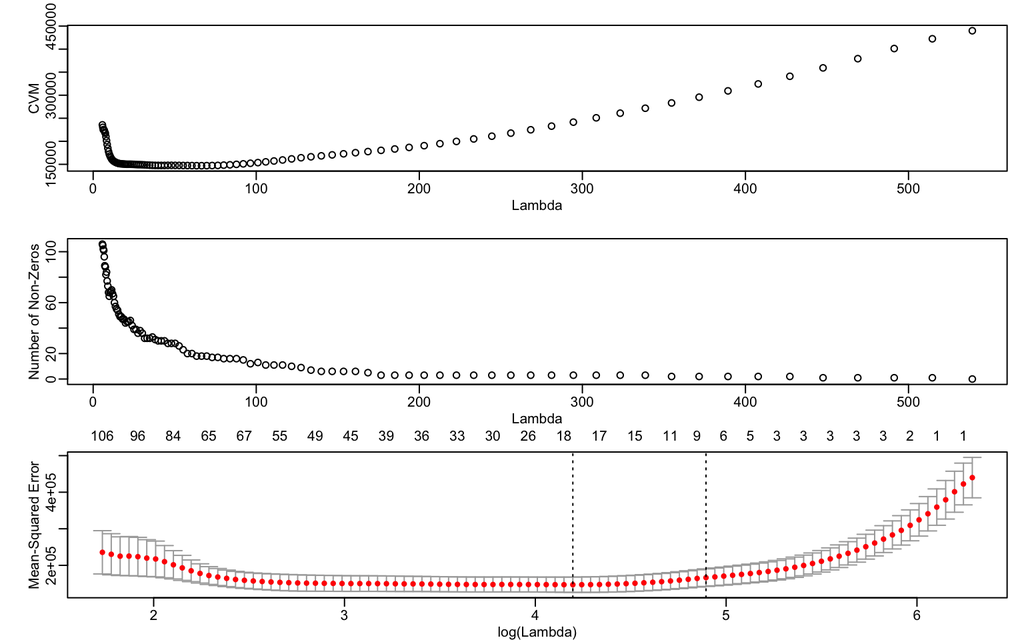

```r
par(mfrow=c(3,1), mar=c(2.5,4,1.5,1), mgp=c(1.5,0.5,0))
#Plot to look at variation of error with lambda
plot(fit.lass.cv$lambda,fit.lass.cv$cvm, xlab = "Lambda", ylab = "CVM")
#Plot to look at variation of number of non zero parameters with lambda
plot(fit.lass.cv$lambda, fit.lass.cv$nzero, xlab="Lambda", ylab="Number of Non-Zeros")
plot(fit.lass.cv)
```

```r
#Extracting the coefficients corresponding to minimum lambda to feed into ols model
coef.min <- coef(fit.lass.cv, s="lambda.min")
coef.min <- coef.min[which(coef.min !=0),]
var.min <- rownames(as.matrix(coef.min))
lm.input <- as.formula(paste("violentcrimes.perpop", "~", paste(var.min[-1], collapse = "+")))
lm.input
```

```
## violentcrimes.perpop ~ race.pctblack:age.pct16to24 + race.pctblack:hisp.percap +
##     race.pctblack:pct.no.english.well + race.pctblack:rent.qrange +
##     pct.pubasst.inc:pct.use.publictransit + white.percap:pct.not.hsgrad +
##     asian.percap:pct.pop.underpov + hisp.percap:pct.pop.underpov +
##     hisp.percap:pct.not.hsgrad + hisp.percap:pct.house.nophone +
##     pct.not.hsgrad:male.pct.divorce + male.pct.divorce:pct.kids.nvrmarried +
##     pct.kids2parents:pct.workmom + pct.kids2parents:pct.house.occup +
##     pct.kids2parents:med.yr.house.built + pct.house.vacant:pct.house.nophone +
##     pct.house.vacant:num.in.shelters + pct.house.nophone:pct.use.publictransit
```

```r
#OLS model using parameters output by LASSO
fit.min.lass <- lm(lm.input, data = data.new)
lm.output <- coef(fit.min.lass)
summary(fit.min.lass)
```

```
##
## Call:
## lm(formula = lm.input, data = data.new)
##
## Residuals:
##      Min       1Q   Median       3Q      Max
## -1001.99  -166.19   -34.74   151.01  1862.39
##
## Coefficients:
##                                           Estimate Std. Error t value
## (Intercept)                              4.142e+02  4.427e+02   0.936
## race.pctblack:age.pct16to24              6.596e-01  3.486e-01   1.892
## race.pctblack:hisp.percap                9.671e-04  6.491e-04   1.490
## race.pctblack:pct.no.english.well        2.860e-01  3.015e-01   0.949
## race.pctblack:rent.qrange               -4.329e-03  3.403e-02  -0.127
## pct.pubasst.inc:pct.use.publictransit    1.531e+00  9.514e-01   1.609
## white.percap:pct.not.hsgrad              5.279e-05  3.387e-04   0.156
## asian.percap:pct.pop.underpov            5.887e-04  1.708e-04   3.446
## hisp.percap:pct.pop.underpov             1.377e-04  6.949e-04   0.198
## hisp.percap:pct.not.hsgrad               8.206e-04  5.290e-04   1.551
## hisp.percap:pct.house.nophone            1.050e-03  1.575e-03   0.667
## pct.not.hsgrad:male.pct.divorce          6.107e-01  4.028e-01   1.516
## male.pct.divorce:pct.kids.nvrmarried     5.500e+00  1.461e+00   3.765
## pct.kids2parents:pct.workmom            -9.508e-02  4.899e-02  -1.941
## pct.kids2parents:pct.house.occup        -6.788e-02  4.781e-02  -1.420
## pct.kids2parents:med.yr.house.built      3.611e-03  3.673e-03   0.983
## pct.house.nophone:pct.house.vacant       6.254e-01  2.071e+00   0.302
## pct.house.vacant:num.in.shelters         4.877e-02  1.572e-02   3.102
## pct.use.publictransit:pct.house.nophone -1.714e+00  2.442e+00  -0.702
##                                         Pr(>|t|)
## (Intercept)                             0.350143
## race.pctblack:age.pct16to24             0.059331 .
## race.pctblack:hisp.percap               0.137165
## race.pctblack:pct.no.english.well       0.343409
## race.pctblack:rent.qrange               0.898828
## pct.pubasst.inc:pct.use.publictransit   0.108454
## white.percap:pct.not.hsgrad             0.876225
## asian.percap:pct.pop.underpov           0.000637 ***
## hisp.percap:pct.pop.underpov            0.843022
## hisp.percap:pct.not.hsgrad              0.121780
## hisp.percap:pct.house.nophone           0.505352
## pct.not.hsgrad:male.pct.divorce         0.130430
## male.pct.divorce:pct.kids.nvrmarried    0.000196 ***
## pct.kids2parents:pct.workmom            0.053088 .
## pct.kids2parents:pct.house.occup        0.156565
## pct.kids2parents:med.yr.house.built     0.326234
## pct.house.nophone:pct.house.vacant      0.762850
## pct.house.vacant:num.in.shelters        0.002079 **
## pct.use.publictransit:pct.house.nophone 0.483316
## ---
## Signif. codes:  0 '***' 0.001 '**' 0.01 '*' 0.05 '.' 0.1 ' ' 1
##
## Residual standard error: 333.5 on 349 degrees of freedom
## Multiple R-squared:  0.761,  Adjusted R-squared:  0.7486
## F-statistic: 61.72 on 18 and 349 DF,  p-value: < 2.2e-16
```

```r
#Model selection using regsubsets to find the best combination of the parameters
fit.final <- regsubsets(violentcrimes.perpop~race.pctblack.age.pct16to24        +       race.pctblack.hisp.percap    +   race.pctblack.pct.no.english.well + race.pctblack.rent.qrange +  pct.pubasst.inc.pct.use.publictransit      +       white.percap.pct.not.hsgrad       +    asian.percap.pct.pop.underpov+ hisp.percap.pct.pop.underpov     +         hisp.percap.pct.not.hsgrad     +      hisp.percap.pct.house.nophone     +    pct.not.hsgrad.male.pct.divorce + male.pct.divorce.pct.kids.nvrmarried      +      pct.kids2parents.pct.workmom    +    pct.kids2parents.pct.house.occup   +  pct.kids2parents.med.yr.house.built +  pct.house.vacant.pct.house.nophone    +    pct.house.vacant.num.in.shelters +  pct.house.nophone.pct.use.publictransit , nvmax=19, method="exhau", data = data.new  )

finalmodel <- function(data.fl, fit.final) # fit.final is an object form regsubsets
{

  # Input: the data frame and the regsubsets output= fit.final
  # Output: the final model variable names
  p <- fit.final$np-1  #  number of  predictors from fit.final
  var.names <- c(names(data.fl)[dim(data.fl)[2]], names(coef(fit.final, p))[-1]) # collect all predictors and y
  data1 <- data.fl[, var.names]  # a subset
  temp.input <- as.formula(paste(names(data1)[1], "~",
                   paste(names(data1)[-1], collapse = "+"),
                   sep = ""))      # get lm() formula

  try.1 <- lm(temp.input, data=data1)  # fit the current model
  largestp <- max(coef(summary(try.1))[2:p+1, 4]) # largest p-values of all the predictors

   while(largestp > .05)   #stop if all the predictors are sig at .05 level

     {p=p-1  # otherwise move to the next smaller model

      var.names <- c(names(data.fl)[dim(data.fl)[2]], names(coef(fit.final, p))[-1])
      data1 <- data.fl[, var.names]

      temp.input <- as.formula(paste(names(data1)[1], "~",
                              paste(names(data1)[-1], collapse = "+"),
                              sep = ""))      # get lm() formula

      try.1 <- lm(temp.input, data=data1)  # fit the current model
      largestp <- max(coef(summary(try.1))[2:p+1, 4]) # largest p-values of all the predictors
      }

  finalmodel <- var.names
  finalmodel
}

#Vector of variable names that is the best model
names <- finalmodel(data.new, fit.final )

lm.input <- as.formula(paste(names[1], "~", paste(names[-1], collapse = "+")))
summary(lm(lm.input, data = data.new))
```

```
##
## Call:
## lm(formula = lm.input, data = data.new)
##
## Residuals:
##      Min       1Q   Median       3Q      Max
## -1027.50  -174.35   -38.75   151.76  1845.75
##
## Coefficients:
##                                        Estimate Std. Error t value
## (Intercept)                           5.262e+02  2.279e+02   2.309
## race.pctblack.age.pct16to24           7.908e-01  2.674e-01   2.957
## race.pctblack.hisp.percap             9.985e-04  4.223e-04   2.365
## asian.percap.pct.pop.underpov         6.099e-04  1.611e-04   3.786
## hisp.percap.pct.not.hsgrad            1.020e-03  3.409e-04   2.992
## pct.not.hsgrad.male.pct.divorce       7.089e-01  3.160e-01   2.244
## male.pct.divorce.pct.kids.nvrmarried  5.578e+00  1.276e+00   4.372
## pct.kids2parents.pct.workmom         -1.061e-01  3.837e-02  -2.766
## pct.house.vacant.num.in.shelters      6.543e-02  1.298e-02   5.040
##                                      Pr(>|t|)
## (Intercept)                           0.02154 *
## race.pctblack.age.pct16to24           0.00331 **
## race.pctblack.hisp.percap             0.01858 *
## asian.percap.pct.pop.underpov         0.00018 ***
## hisp.percap.pct.not.hsgrad            0.00296 **
## pct.not.hsgrad.male.pct.divorce       0.02547 *
## male.pct.divorce.pct.kids.nvrmarried 1.61e-05 ***
## pct.kids2parents.pct.workmom          0.00597 **
## pct.house.vacant.num.in.shelters     7.40e-07 ***
## ---
## Signif. codes:  0 '***' 0.001 '**' 0.01 '*' 0.05 '.' 0.1 ' ' 1
##
## Residual standard error: 332.2 on 359 degrees of freedom
## Multiple R-squared:  0.756,  Adjusted R-squared:  0.7506
## F-statistic:   139 on 8 and 359 DF,  p-value: < 2.2e-16
```

We have 8 features in the final model for the case that includes pair wise interaction terms.

2. Comparing the final models with the ones from **B)**, which one would you use? Commenting on your choice.

We would want to use the final model we get from part B since it has many fewer variables than our final answer for part B+, which makes interpretations easier. Both the final model from part B and part B+ have predictors that are all significant, but the predictors in the final model from part B are all more significant than some of the predictors in the final model from part B+, which is another reason we would choose the final model in part B. Also, teh model from part B+ is more complex, which might result in overfitting the data.